# `drmr`: A Bayesian approach to Dynamic Range Models in `R`

Available at lcgodoy.me/slides/2025-esa/

Lucas da Cunha Godoy

ldcgodoy@ucsc.com

EEB Department, UCSC

2025-08-13

# Introduction

## The Challenge & Limits of SDMs

- Critical Challenge: Predicting species’ responses to global environmental change is vital for conservation and management.
- Usual Tool: Species Distribution Models (SDMs) have been the workhorse, correlating occurrences with environmental variables.
- Limitations of SDMs:
  - Struggle to predict responses under novel future conditions (Pagel and Schurr 2012).
  - Lack Mechanism: They do not explicitly model the underlying biological processes.
  - Equilibrium Assumption: Often violated (Guisan and Thuiller 2005).

## Dynamic Range Models (DRMs): A Mechanistic Approach

- DRMs explicitly incorporate demographic processes that drive range dynamics (Pagel and Schurr 2012).
- Allows linking environmental drivers directly to specific processes.
- Potential for more robust forecasting under novel conditions.
- Why are they rarely in practice? Despite conceptual appeal, DRMs have been underutilized due to their complexity and computational challenges to fit these models.

## Introducing `drmr`: Making DRMs Accessible

- Goal: Bridge the gap between DRM potential and practical application.
- Key Features:
  - Makes age-structured DRMs readily available in a Bayesian framework.
  - Leverages `Stan` via `cmdstanr` for efficient fitting (Gabry et al. 2024).
  - User-friendly interface.
  - Easily relate environmental drivers to specific recruitment and survival.

# Age-structured DRM

## Setup & Notation

- $Y_{t, i}$ is the observed density of individuals (all ages) at time $t$ and site $i$, and it follows a zero-augmented probability distribution.
- $\rho_{t, i} = \mathrm{P}(Y_{t, i} = 0)$: Probability of absence.
- $\mu_{t, i} = \sum_{a} \lambda_{a, t, i}$: Expected total density.
- $\lambda_{a, t, i}$: Expected age-specific density.
  - Biological processes (recruitment, survival, and movement) are encoded through these parameters.

## Model assumptions!

[figure not shown]

## Recruitment & survival

- The recruitment density is driven by the environmental conditions in the current year:
  $$\log(\lambda_{1, t, i}) =
  \mathbf{x}^{(r)}_{t, i} \mathbf{\beta}_{r} + z^{(r)}_{t, i}$$
- The density of individuals who survive from the previous year and their respective estimated survival rate:
  $$\lambda_{a, t, i} = s_{a - 1, t - 1, i} \cdot \lambda_{a - 1, t - 1, i},$$
  where
  $$\log(s_{a, t, i}) = \mathbf{x}^{(s)}_{t, i}
  \mathbf{\beta}_{s} + z^{(s)}_{t, i} - f_{a, t}$$

## Code & workflow

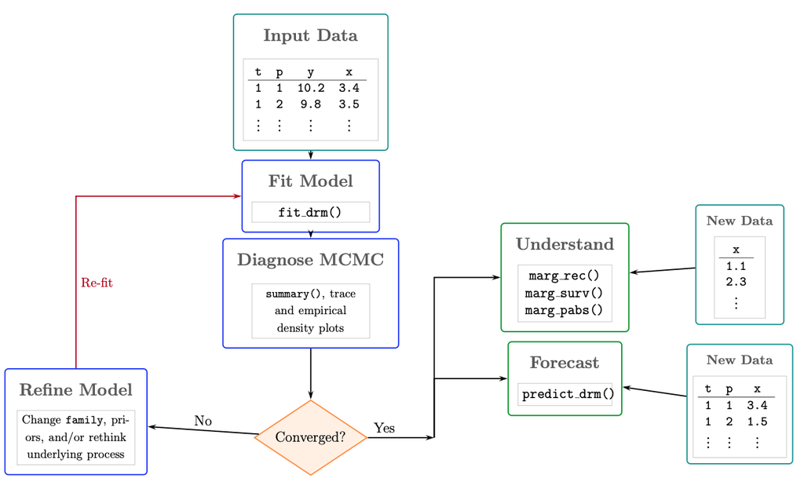

# Illustration with real data

## Summer Flounder Dataset

- An example analysis uses Summer flounder (*Paralichthys dentatus*) data from 1982-2016 NOAA bottom trawl surveys (Fredston et al. 2025) to illustrate the package’s features.
- The data spans the US Atlantic coast (Cape Hatteras, NC to the Canada/Maine border) and was aggregated from individual hauls into 10 latitudinal patches with varying areas.
- Response variable: Density (count per unit area).
- Environmental drivers: SST and SBT.

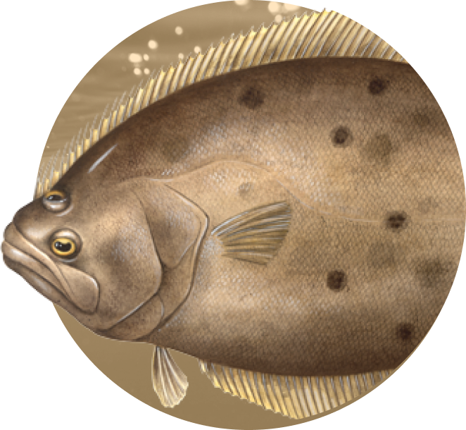

Figure source: [ASMFC](https://asmfc.org/species/summer-flounder/)

## Models fitted to the data

| Model | Non-neg. PDF | $\rho_{i, t}$ | Recruitment (or Density) | Survival |
| --- | --- | --- | --- | --- |
| **DRM (rec)** | Gamma | Effort + estimated density | SST + SST<sup>2</sup> + AR(1) | Intercept + $f_{a, t}$ |
| **DRM (surv)** | Gamma | Effort + estimated density | AR(1) | SBT + SBT<sup>2</sup> + $f_{a, t}$ |
| **SDM (GLM)** | LogNormal | Effort | SST + SST<sup>2</sup> |  |

## Sample code for DRM (rec)

```r
drm_rec <-
  fit_drm(.data = dat_train,
          y_col = "dens", ## response variable: density
          time_col = "year", ## vector of time points
          site_col = "patch",
          family = "gamma", ## other options: lognormal, loglogistic
          seed = 202505,
          formula_zero = ~ 1 + c_hauls,
          formula_rec = ~ 1 + c_sst + I(c_sst * c_sst),
          formula_surv = ~ 1,
          f_mort = f_train,
          n_ages = NROW(f_train),
          adj_mat = adj_mat, ## A matrix for movement routine
          ages_movement = c(0, 0,
                            rep(1, 12),
                            0, 0), ## ages allowed to move
          .toggles = list(ar_re = "rec", ## other options: "surv", "dens"
                          movement = 1,
                          est_surv = 1,
                          est_init = 0,
                          minit = 1),
          .priors = list(pr_phi_a = 1, pr_phi_b = .1,
                         pr_alpha_a = 4.2, pr_alpha_b = 5.8,
                         pr_zeta_a = 7, pr_zeta_b = 3))
```

## Effect of environmental variables

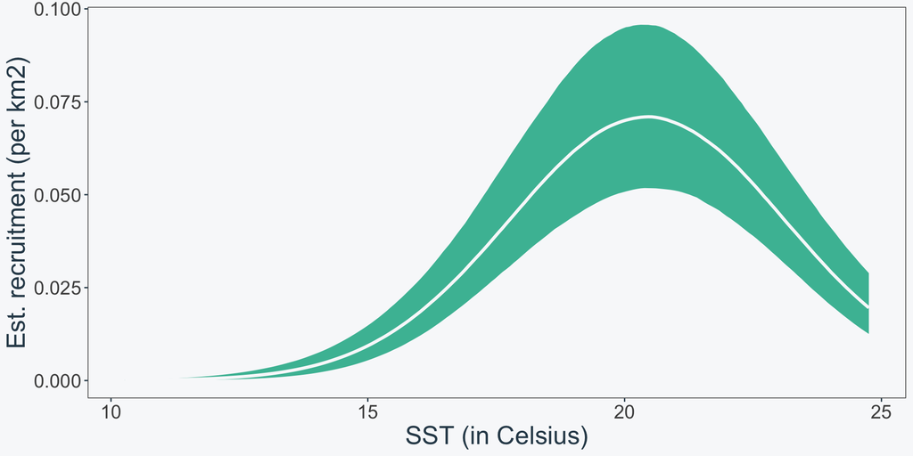

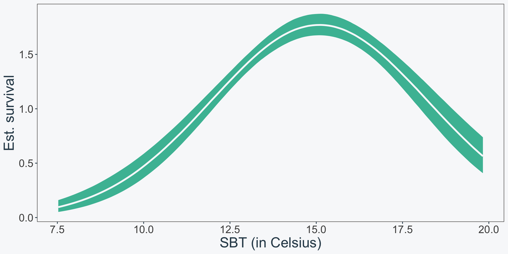

## Sample code for forecasting

- The `predict_drm` function requires at least three arguments:
  - `drm`: Output of a `fit_drm` call
  - `new_data`: A `data.frame` where we seek to obtain predictions
  - `seed`: For reproducibility

```r
forecast_rec <- predict_drm(drm = drm_rec,                         # Required
                            new_data = dat_test,                   # Required
                            seed = 152,                            # Required
                            f_test = f_test,                       # Optional
                            past_data = filter(dat_train,          # Optional
                                               year == max(year)))
```

## Forecasts visualization & comparison

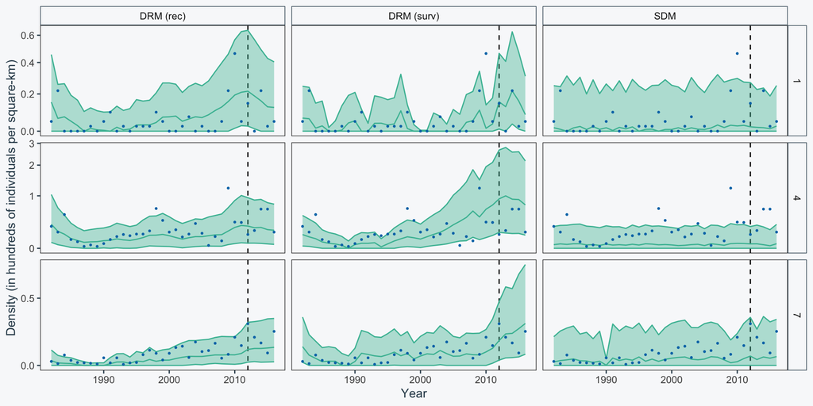

# Concluding remarks

## Highlights

- The `drmr` substantially lowers the barrier for ecologists to use the DRM in their applications.
- The code is easy to use and takes advantage of what has been developed for `Stan`: visualization, diagnostic tools, and estimation.
- `drmr` allows for empirically testing which processes are more important to predict the distribution of a species.
- The more complex a model is, the more (and better) data we need to be able to estimate those relationships.

## Future work

- Include population dynamic models that explicitly relate adult density to recruitment (e.g., Ricker, Belverton-Holt)
- GAM-like non-parametric relationships between processes and the environment
- Support for length-composition data
- More realistic movement/dispersal routines

## Acknowledgments

[figure not shown]

[figure not shown]

### References

Fredston, A., Ovando, D., Godoy, L. da C., Kong, J., Muffley, B., Thorson, J. T., and Pinsky, M. (2025), “Dynamic range models improve the near-term forecast for a marine species on the move,” *Ecology Letters*, 00, (under review). https://doi.org/10.32942/X24D00.

Gabry, J., Češnovar, R., Johnson, A., and Bronder, S. (2024), *[cmdstanr: R interface to CmdStan](https://github.com/stan-dev/cmdstanr)*.

Guisan, A., and Thuiller, W. (2005), “Predicting species distribution: Offering more than simple habitat models,” *Ecology letters*, Wiley Online Library, 8, 993–1009. https://doi.org/https://doi.org/10.1111/j.1461-0248.2005.00792.x.

Pagel, J., and Schurr, F. M. (2012), “Forecasting species ranges by statistical estimation of ecological niches and spatial population dynamics,” *Global Ecology and Biogeography*, 21, 293–304. https://doi.org/https://doi.org/10.1111/j.1466-8238.2011.00663.x.